# Democrats vs Republicans

In this study, I focus on U.S. Presidential inauguration speeches of 8 presidents in the recent 50 years . Here I conduct a brief comparison of speeches by the parties to which the presidents stand for. I am interested in the similarities and the difference of the speeches in terms of length and content.

[output not shown]

### List of Presidents of United States from 1969 to 2018

| id | President | Presidency | Party |
| --- | --- | --- | --- |
| 1 | Richard Nixon | 1969-1974 | Republican |
| 2 | Jimmy Carter | 1977-1981 | Democratic |
| 3 | Ronald Reagan | 1981-1989 | Republican |
| 4 | George Bush | 1989-1993 | Republican |
| 5 | William J. Clinton | 1993-2001 | Democratic |
| 6 | George W. Bush | 2001-2009 | Republican |
| 7 | Barack Obama | 2009-2017 | Democratic |
| 8 | Donald J. Trump | 2017-Incumbent | Republican |

### Part 1. Length of the Inaugural Addresses

In the recent 40 years, the average number of words used by each president fluctuate between 1200 to 2500.It seems like presidents of the Democratic Party delivered slightly shorter speeches, but the difference is not significant.Presidents known to have good public - speaking techniques, such as Ronald Reagan and Barack Obama, gave longer speeches.

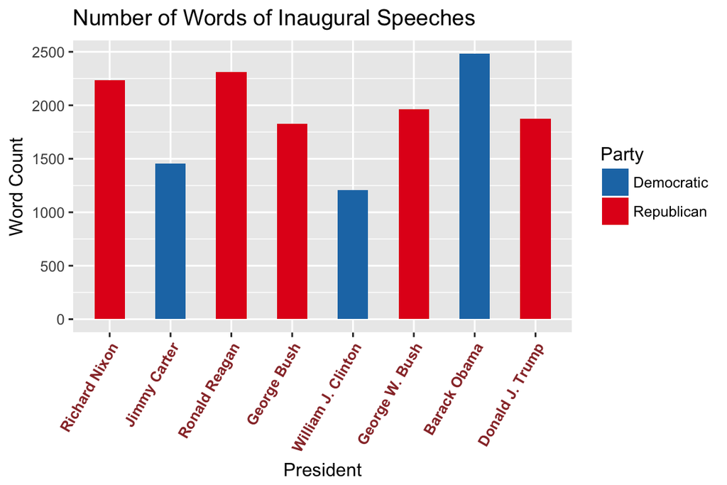

### Part 2. Textual Analysis

In the text cleaning process, besides the usual procedure, I manually removed some uninformative words such as will, can, and let and replaced some synonyms. After that, I plot word clouds of the most frequently used 100 words for presidents of 2 Parties and look at their similarity.

##### a.Republican

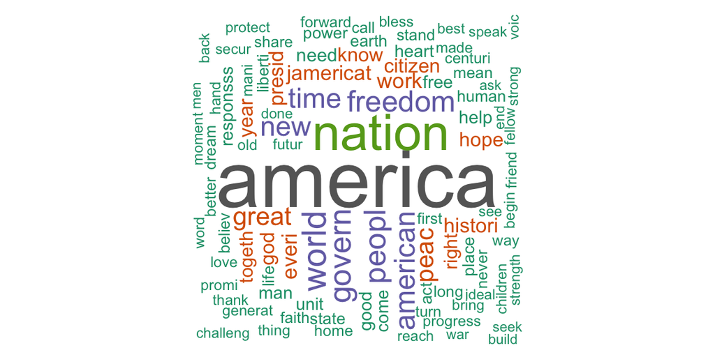

#### b.Democratic

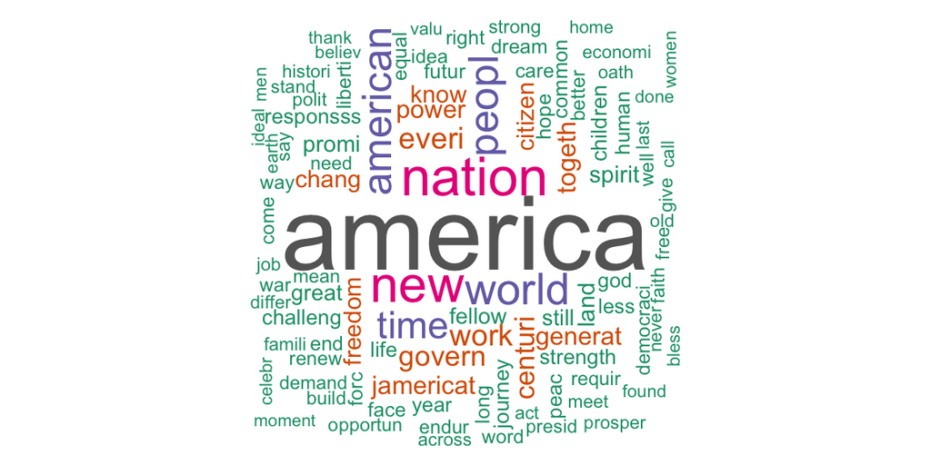

##### c. Top 20 Words shared by Presidents of Two Parties

```
[1] 5.1 4.1 2.1 2.1
```

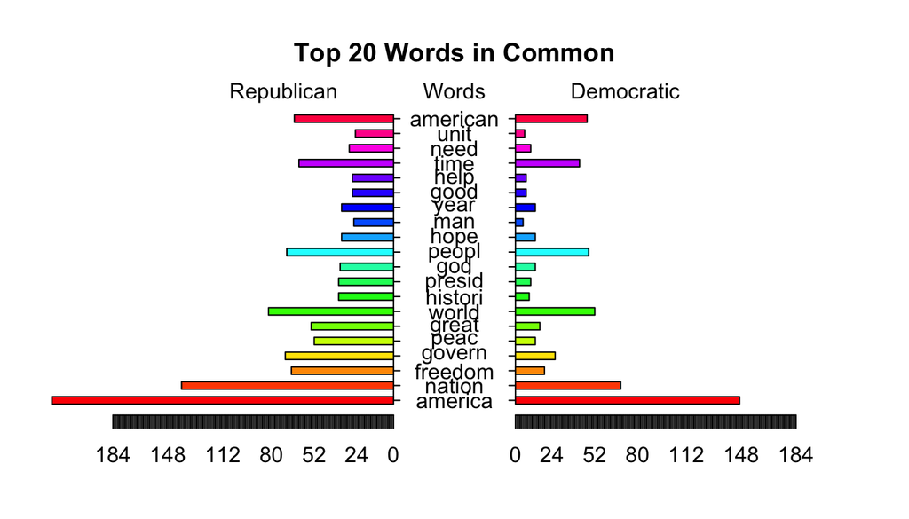

The most frequent words shared are America, people, world, nation, government, etc. This is expected because inaugural addresses are used to present presidents’ visions and goals for the country, their promises to the people, and the missions for the government. Words like peace, freedom are long-term goals that could not be emphasized enough. Here I am interested in the word history and want to know its context.So I found 10 words that are most correlated to the word history,and it seems like when the presidents look back in history,they care about aid they received, wins, threatens to lives of the people, and rebuilding the country.

```
  almost      aid  million      pay      win     back     step threaten     weve  rebuild
    0.82     0.82     0.76     0.76     0.76     0.75     0.71     0.69     0.69     0.66
```

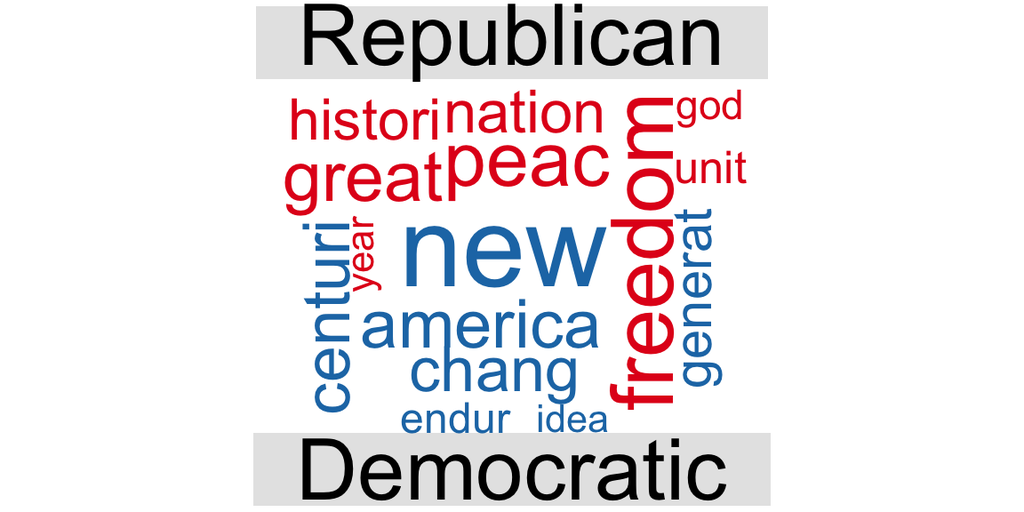

Code from https://s3.amazonaws.com/assets.datacamp.com/production/course_935/ch2_pdf_slides.pdf

```
Democratic:  chang land spirit fellow still children strength common end equal forc idea renew requir war well word
```

```
Republican:  histori presid need good help free man heart unit place act earth state go believ mean stand call faith first home never share forward mani turn begin bless friend hand love made old progress thing
```

It seems like presidents from different parties differ in philosophies. Presidents from the Democratic Party talk more about equality, children, and land issues. Whereas presidents from the Republican party talks more about freedom, housing policies,and state. The findings matche two parties’ long term ideologies.

#### e. Closer look at some ambiguous words and its syntax

Here again, I found the 10 words that are most correlated with the word “never” which appear very often in speeches from the Republican Party but not from the Democratic Party. “Never” which is associated with negative sentiments is related to immigration. For presidents of the Democratic Party, the word “future” is associated with dignity and school which is consistant with their political stands.

```
    mani   follow   demand    along    anyth    arriv  convict   exampl   immigr knowledg
    0.97     0.90     0.89     0.85     0.85     0.85     0.85     0.85     0.85     0.85
```

```
   year    life digniti  school  effort    guid   secur   creat    free journey
   0.99    0.94    0.93    0.93    0.92    0.90    0.89    0.88    0.88    0.88
```

### Part 2. Topics Modeling of Inaugural Speeches

I did LDA on inaugural speeches for all U.S presidents and take a close look at the 8 presidents we are interested in. We study how often presidents address seven topics: Economy , Equality, Misc, Legislation, Government, Reform,Freedom. In the plot of the average frequency presidents adresse those 7 topics, it seems like there is only subtle difference between parties.Republicans address freedom and government slightly more often than Democrats which is consistent from our findings before.

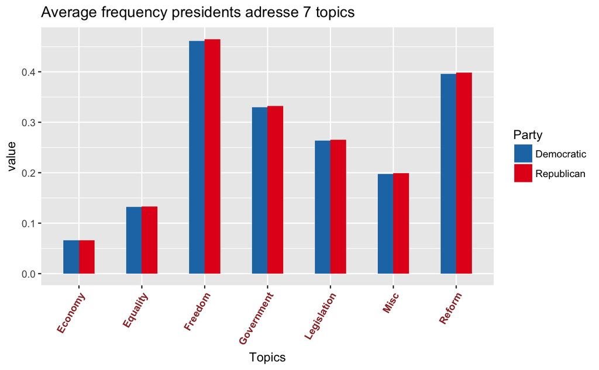

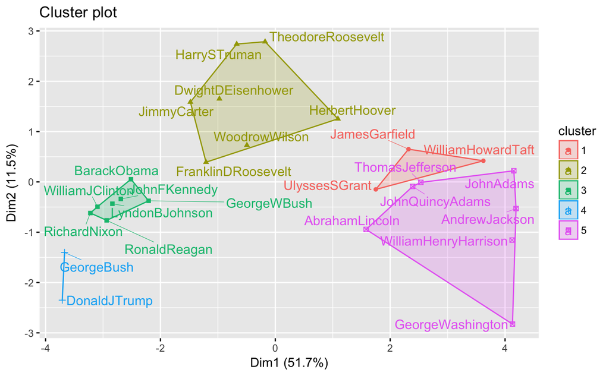

### Conclusion

For the 8 recent presidents, their inaugural speeches cover very similar topics but still differ by party. And when we take a closer look at the words presidents used in speeches, it seems like the contents differ by parties and match the party’s ideologies.